# Extended_EDA

```python
import pandas as pd
import numpy as np
import warnings

warnings.simplefilter(action='ignore', category=pd.errors.DtypeWarning)

df = pd.read_csv("./RIPA_2023_Merged_Cities.csv")
```

```python
# Show unique traffic violation types
violation_types = df['RFS_TRAFFIC_VIOLATION_TYPE'].dropna().unique()
violation_types = sorted(violation_types)

for v in violation_types:
    print(f"- {v}")
```

```
- 1.0
- 2.0
- 3.0
```

```python
missing_count = df['RFS_TRAFFIC_VIOLATION_TYPE'].isnull().sum()
total_rows = len(df)
missing_percent = (missing_count / total_rows) * 100

print(f"Missing values in RFS_TRAFFIC_VIOLATION_TYPE: {missing_count} out of {total_rows} rows")
print(f"Missing percentage: {missing_percent:.2f}%")
```

```
Missing values in RFS_TRAFFIC_VIOLATION_TYPE: 20664 out of 70211 rows
Missing percentage: 29.43%
```

```python
# Remove rows where RFS_TRAFFIC_VIOLATION_TYPE is missing
df = df.dropna(subset=['RFS_TRAFFIC_VIOLATION_TYPE'])

# Confirm the change
print(f"Remaining rows after removal: {len(df)}")
```

```
Remaining rows after removal: 49547
```

```python
# cleaning the numerics from column
df['STOP_DURATION_CLEAN'] = df['STOP_DURATION'].astype(str).str.extract(r'(\d+)').astype(float)
```

```python
mean_duration = df['STOP_DURATION_CLEAN'].mean()
print(f"Mean Stop Duration: {mean_duration:.2f} minutes")
```

```
Mean Stop Duration: 17.03 minutes
```

```python
# Extract numeric minutes if STOP_DURATION is not already numeric
df['STOP_DURATION_CLEAN'] = df['STOP_DURATION'].astype(str).str.extract(r'(\d+)').astype(float)

# Drop NaNs to avoid plot errors
duration_data = df['STOP_DURATION_CLEAN'].dropna()
```

```python
Q1 = duration_data.quantile(0.25)
Q3 = duration_data.quantile(0.75)
IQR = Q3 - Q1

lower_bound = Q1 - 1.5 * IQR
upper_bound = Q3 + 1.5 * IQR

# Filter out the outliers
filtered_duration = duration_data[(duration_data >= lower_bound) & (duration_data <= upper_bound)]

print(f"Original count: {len(duration_data)}")
print(f"Filtered count: {len(filtered_duration)}")
print(f"Outliers removed: {len(duration_data) - len(filtered_duration)}")
```

```
Original count: 49547
Filtered count: 44738
Outliers removed: 4809
```

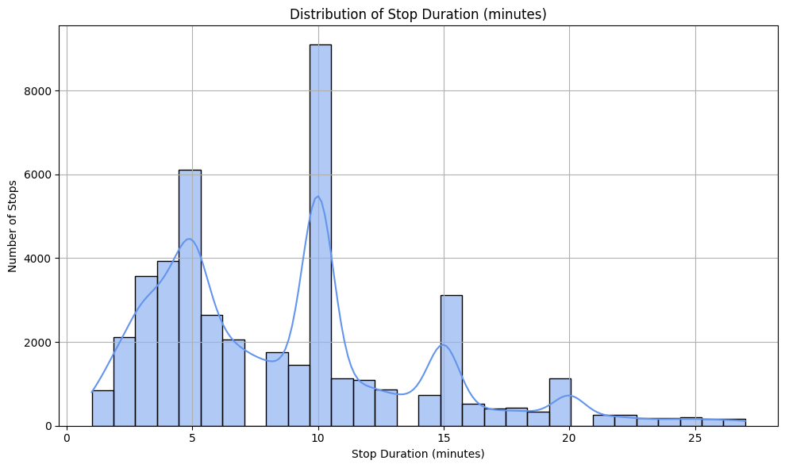

```python
import seaborn as sns
import matplotlib.pyplot as plt

plt.figure(figsize=(10, 6))
sns.histplot(data=filtered_duration, bins=30, kde=True, color='cornflowerblue')

plt.title("Distribution of Stop Duration (minutes)")
plt.xlabel("Stop Duration (minutes)")
plt.ylabel("Number of Stops")
plt.grid(True)
plt.tight_layout()
plt.show()
```

```python
from scipy.stats import shapiro

# Sample only 5000 rows if you have more
sample = filtered_duration.sample(n=5000, random_state=1)

stat, p = shapiro(sample)
print(f"Shapiro-Wilk Test → W = {stat:.4f}, p = {p:.4f}")
if p < 0.05:
    print("Data is NOT normally distributed.")
else:
    print("Data is normally distributed.")
```

```
Shapiro-Wilk Test → W = 0.9191, p = 0.0000
Data is NOT normally distributed.
```

### Hypothesis test:

**Null Hypothesis (H₀):**  
The type of traffic violation does **not significantly affect** the stop duration.  
*(All violation types have the same distribution of stop times.)*

**Alternative Hypothesis (H₁):**  
At least one traffic violation type **significantly affects** the stop duration.  
*(There is a difference in stop time distributions between violation types.)*

```python
from scipy.stats import kruskal

# Ensure STOP_DURATION_CLEAN is numeric
df['STOP_DURATION_CLEAN'] = df['STOP_DURATION'].astype(str).str.extract(r'(\d+)').astype(float)

# Drop missing values
filtered_df = df.dropna(subset=['STOP_DURATION_CLEAN', 'RFS_TRAFFIC_VIOLATION_TYPE'])

# Group data by violation type
grouped_data = [
    group['STOP_DURATION_CLEAN'].values
    for _, group in filtered_df.groupby('RFS_TRAFFIC_VIOLATION_TYPE')
    if len(group) > 1  # Avoid groups with only one sample
]

# Run Kruskal–Wallis H-test
stat, p = kruskal(*grouped_data)
print(f"Kruskal–Wallis Test → H = {stat:.2f}, p = {p:.4f}")

if p < 0.05:
    print("Reject H₀ → At least one violation type significantly affects stop duration.")
else:
    print("Fail to reject H₀ → No significant effect from violation type.")
```

```
Kruskal–Wallis Test → H = 94.89, p = 0.0000
Reject H₀ → At least one violation type significantly affects stop duration.
```

## So which violation is responsible here?

```python
# Drop missing values
filtered_df = df.dropna(subset=['STOP_DURATION_CLEAN', 'RFS_TRAFFIC_VIOLATION_TYPE'])

# Calculate average stop duration per violation type
mean_durations = (
    filtered_df
    .groupby('RFS_TRAFFIC_VIOLATION_TYPE')['STOP_DURATION_CLEAN']
    .mean()
    .sort_values(ascending=False)
)

# Show top 5 violation types with highest average stop durations
print("Violation types with longest average stop durations:")
print(mean_durations.head())

# Print the one that affects it the most
most_impactful = mean_durations.idxmax()
max_duration = mean_durations.max()
print(f"\nType: {int(most_impactful)} causes the longest average stop time: {max_duration:.2f} minutes")
```

```
Violation types with longest average stop durations:
RFS_TRAFFIC_VIOLATION_TYPE
3.0    22.156731
2.0    15.931865
1.0    15.740057
Name: STOP_DURATION_CLEAN, dtype: float64

Type: 3 causes the longest average stop time: 22.16 minutes
```

| Code | Description |
| --- | --- |
| 1 | **Moving Violation** — Offenses related to vehicle movement, such as speeding, running a stop sign, reckless driving. |
| 2 | **Equipment Violation** — Issues related to the vehicle’s equipment or registration, such as broken lights, expired registration, missing mirrors. |
| 3 | **Non-moving Violation / Blank** — Non-moving offenses like parking violations, administrative stops, or when the violation type was not recorded. |

```python
import pandas as pd

actions = ['ADS_HANDCUFFED', 'ADS_SEARCH_PERSON', 'ADS_PATCAR_DETENT', 'ADS_SEARCH_PERS_CONSEN']

for action in actions:
    group0 = filtered_df[filtered_df[action] == 0]['STOP_DURATION_CLEAN']
    group1 = filtered_df[filtered_df[action] == 1]['STOP_DURATION_CLEAN']


    print(f"Action: {action}")
    print(f"Median duration (No): {group0.median():.2f}")
    print(f"Median duration (Yes): {group1.median():.2f}\n")
```

```
Action: ADS_HANDCUFFED
Median duration (No): 9.00
Median duration (Yes): 69.00

Action: ADS_SEARCH_PERSON
Median duration (No): 9.00
Median duration (Yes): 45.00

Action: ADS_PATCAR_DETENT
Median duration (No): 9.00
Median duration (Yes): 15.00

Action: ADS_SEARCH_PERS_CONSEN
Median duration (No): 40.50
Median duration (Yes): 30.00
```

### Observations: Cause-Effect Analysis of Police Actions on Stop Duration

- **Handcuffing (`ADS_HANDCUFFED`):**  
  Median stop duration is **9 minutes** when no handcuffing occurs, versus **69 minutes** when handcuffing is applied.  
  → **Handcuffing is strongly associated with much longer stop durations.**
- **Person Search (`ADS_SEARCH_PERSON`):**  
  Median stop duration is **9 minutes** without a person search, and **45 minutes** with a search.  
  → **Conducting a search significantly increases stop duration.**
- **Patrol Car Detention (`ADS_PATCAR_DETENT`):**  
  Median stop duration is **9 minutes** when no detention in patrol car occurs, and **15 minutes** when it does.  
  → **Patrol car detention modestly increases stop duration.**
- **Consent to Search Person (`ADS_SEARCH_PERS_CONSEN`):**  
  Median stop duration is **40.5 minutes** when consent is *not* given, and **30 minutes** when consent *is* given.  
  → **Stops where consent to search is given tend to be shorter than those without consent.**

These observations suggest that **certain police actions such as handcuffing and searches substantially contribute to longer stop times**, while consent-based searches may be associated with comparatively shorter durations.

```
R² score on test set: 0.0100
Mean Absolute Error: 32.16
Mean Squared Error: 10904.58
```

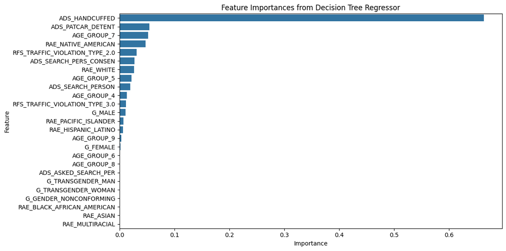

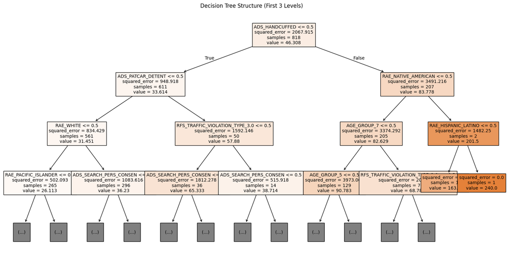

```python
import pandas as pd
import matplotlib.pyplot as plt
import seaborn as sns

from sklearn.tree import DecisionTreeRegressor, plot_tree
from sklearn.model_selection import train_test_split
from sklearn.preprocessing import OneHotEncoder
from sklearn.compose import ColumnTransformer
from sklearn.pipeline import Pipeline
from sklearn.metrics import r2_score, mean_absolute_error, mean_squared_error

# Prepare target variable
df['STOP_DURATION_CLEAN'] = df['STOP_DURATION'].astype(str).str.extract(r'(\d+)').astype(float)

# Select relevant features (add/remove based on your preference)
feature_cols = [
    'RFS_TRAFFIC_VIOLATION_TYPE',
    'ADS_HANDCUFFED',
    'ADS_SEARCH_PERSON',
    'ADS_PATCAR_DETENT',
    'ADS_ASKED_SEARCH_PER',
    'ADS_SEARCH_PERS_CONSEN',
    'AGE_GROUP',
    'G_MALE',
    'G_FEMALE',
    'G_TRANSGENDER_MAN',
    'G_TRANSGENDER_WOMAN',
    'G_GENDER_NONCONFORMING',
    'RAE_WHITE',
    'RAE_BLACK_AFRICAN_AMERICAN',
    'RAE_HISPANIC_LATINO',
    'RAE_ASIAN',
    'RAE_NATIVE_AMERICAN',
    'RAE_PACIFIC_ISLANDER',
    'RAE_MULTIRACIAL',
    'REASON_FOR_STOP'
]

# Drop rows with missing values in features or target
data = df.dropna(subset=feature_cols + ['STOP_DURATION_CLEAN'])

X = data[feature_cols].copy()
y = data['STOP_DURATION_CLEAN']

# Convert categorical columns to string type (for encoding)
categorical_features = ['RFS_TRAFFIC_VIOLATION_TYPE', 'AGE_GROUP', 'REASON_FOR_STOP']
for col in categorical_features:
    X[col] = X[col].astype(str)

# Numerical features are the rest
numerical_features = [col for col in feature_cols if col not in categorical_features]

# Train-test split
X_train, X_test, y_train, y_test = train_test_split(X, y, test_size=0.2, random_state=42)

# Preprocessing pipeline
preprocessor = ColumnTransformer(
    transformers=[
        ('cat', OneHotEncoder(drop='first', sparse_output=False), categorical_features),
        ('num', 'passthrough', numerical_features)
    ])


# Decision Tree Regressor pipeline
pipeline = Pipeline(steps=[
    ('preprocessor', preprocessor),
    ('regressor', DecisionTreeRegressor(random_state=42, max_depth=5))
])

# Train model
pipeline.fit(X_train, y_train)

# Predict on test set
y_pred = pipeline.predict(X_test)

# Evaluate model
print(f"R² score on test set: {r2_score(y_test, y_pred):.4f}")
print(f"Mean Absolute Error: {mean_absolute_error(y_test, y_pred):.2f}")
print(f"Mean Squared Error: {mean_squared_error(y_test, y_pred):.2f}")

# Extract feature importances
model = pipeline.named_steps['regressor']
ohe = pipeline.named_steps['preprocessor'].named_transformers_['cat']
encoded_cat_features = ohe.get_feature_names_out(categorical_features)
feature_names = list(encoded_cat_features) + numerical_features

importances = model.feature_importances_
feature_importances = sorted(zip(feature_names, importances), key=lambda x: x[1], reverse=True)

# Plot feature importances
plt.figure(figsize=(12,6))
sns.barplot(x=[f[1] for f in feature_importances], y=[f[0] for f in feature_importances])
plt.title("Feature Importances from Decision Tree Regressor")
plt.xlabel("Importance")
plt.ylabel("Feature")
plt.tight_layout()
plt.show()

# Visualize the decision tree (limited depth)
plt.figure(figsize=(20,10))
plot_tree(model, feature_names=feature_names, filled=True, max_depth=3, fontsize=10)
plt.title("Decision Tree Structure (First 3 Levels)")
plt.show()
```

### Observations from Decision Tree Regressor

#### 1. Feature Importance Analysis

- The most important feature is `ADS_HANDCUFFED`, contributing to over 65% of the model’s decisions. This indicates that whether a person was handcuffed is the strongest predictor of the target variable.
- Other notable features with moderate importance include:
  - `ADS_PATCAR_DETENT` (patrol car detention)
  - `AGE_GROUP_7`
  - `RAE_NATIVE_AMERICAN` (racial/ethnic group)
  - `RFS_TRAFFIC_VIOLATION_TYPE_2.0`
- A large number of features have very low or zero importance. These include many gender-related and racial/ethnic indicators like `RAE_ASIAN`, `G_TRANSGENDER_MAN`, etc., indicating they did not contribute meaningfully to the model’s predictions.

#### 2. Decision Tree Structure (First 3 Levels)

- The first split in the tree is based on `ADS_HANDCUFFED <= 0.5`, confirming its critical role in the model.
  - If the person was **not handcuffed**, the tree then checks `ADS_PATCAR_DETENT`, followed by features like `RAE_WHITE` and `ADS_SEARCH_PERS_CONSEN`.
    - These paths result in relatively moderate prediction values (e.g., 26 to 65).
  - If the person **was handcuffed**, the tree checks `RAE_NATIVE_AMERICAN`, followed by features like `AGE_GROUP_7`, `RAE_HISPANIC_LATINO`, and `AGE_GROUP_5`.
    - One path leads to a predicted value of **240.0** for a single data point, suggesting an extreme or outlier case.

#### 3. Insights

- The model heavily relies on handcuffing status, followed by other law enforcement actions and demographic indicators.
- Certain racial/ethnic combinations (e.g., `RAE_NATIVE_AMERICAN` and `RAE_HISPANIC_LATINO`) in conjunction with being handcuffed result in higher predicted values, which could indicate potential bias.
- The influence of gender features is negligible in this model.
- The tree may be capturing some highly specific patterns, raising the need for further analysis around fairness and generalizability.